# Hypothesis Testing, Simulation, and Power

Bill 607

September 29, 2016

## 1. Probability Density Distributions

Every probability distribution in R - whether in the base package or in other packages - typically obeys a standard naming conventions. For some distribution, `dist`, then `ddist` is the function for it’s density, `pdist` would give you p-values, `qdist` allows you to get the value of an observation that will produce a given p-value, and `rdist` uses the distribution to generate random numbers.

### 1.1 Normal and Continuous Densities

A normal distribution in R is defined by it’s mean and standard deviation. To get a point density for a normal distribution, `dnorm()` accepts an obsered value, a `mean` argument, and a `sd` argument. The default mean and SD are for a standard normal distribution.

Let’s say we wanted to get the density from an observation of 5 from a distribution with mean 8 and sd of 3.

```r
dnorm(5, mean = 8, sd = 3)
```

```
## [1] 0.08065691
```

Woo! Number!

So, I’ve been plotting all kinds of distributions over the last few weeks. To do that, all I’ve needed was the density over a wide range of values. So, using this distribution, let’s plot the normal curve from 0 to 16. For this, we’d give dnorm a vector instead of a single observation.

```r
dens_frame <- data.frame(x = seq(0, 16, length.out = 200))

#note - you could do this with mutate! But I like $
dens_frame$density <- dnorm(dens_frame$x, mean = 8, sd = 3)
```

That produces a lot of numbers - but we can feed them easily ito ggplot2.

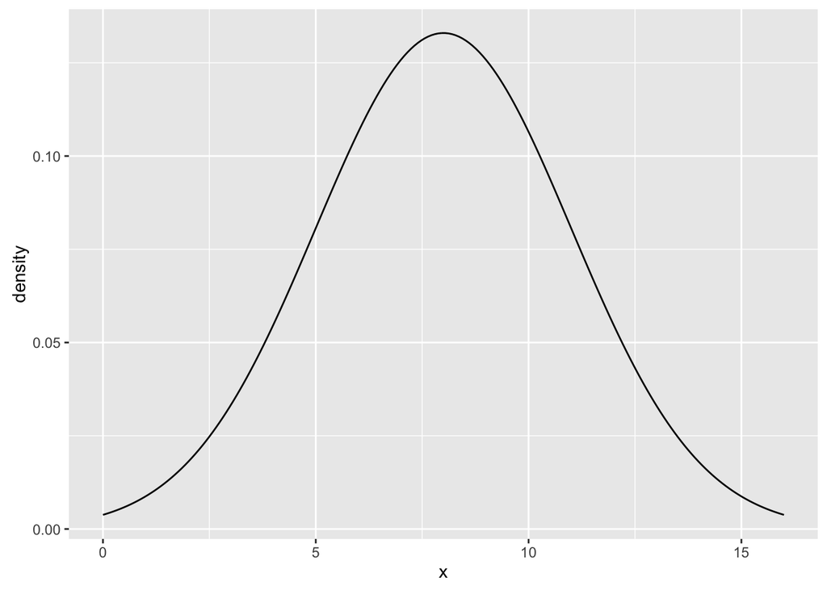

```r
library(ggplot2)

norm_dens <- ggplot(dens_frame,
                    mapping=aes(x=x, y=density)) +
  geom_line()

norm_dens
```

Neat!

We’ve also already seen normal distributions in action to generate random variables.

```r
rnorm(10, mean = 8, sd=3)
```

```
##  [1]  6.308199 10.575167  9.638887  9.392137  9.415474  7.043890  3.751772
##  [8]  4.949667  5.915964 10.836236
```

### 1.2 Poisson and Discrete Densities

What about discrete distributions? For the poisson distribution, we have the `dpois()` function for density, which just takes `lambda` as its argument to define the distribution. So, assuming a lambda of 10, what’s the probability of an observation of 3?

```r
dpois(3, lambda=10)
```

```
## [1] 0.007566655
```

```r
dpois(1.5, lambda=10)
```

```
## [1] 0
```

Plotting is a wee bit funnier, as these distributions are discrete.

```r
pois_frame = data.frame(x = 0:20)

#note - you could do this with mutate! But I like $
pois_frame$density <- dpois(pois_frame$x, lambda = 10)
```

So how to plot? Line plots are… dishonest. We need to show the discrete nature of the distribution. So, we have `geom_bar` to come to our rescue. `stat="identity"` means just plot what value is supplied. And we can monkey with the bar width to express the discrete nature of the distribution.

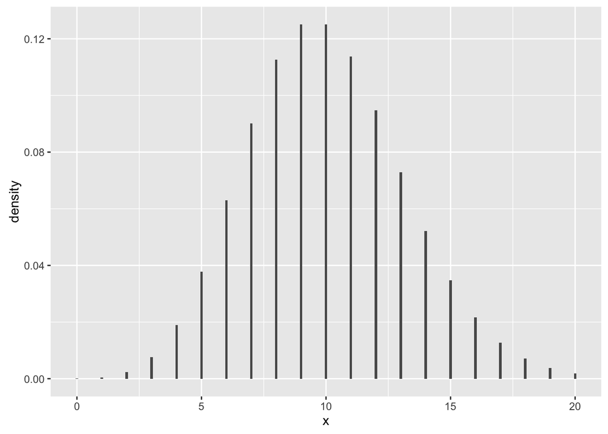

```r
ggplot(pois_frame) +
  aes(x=x, y=density) +
  geom_bar(width=0.1, stat="identity")
```

### 1.3 Exercises: Exploring Distributions

OK, let’s try getting the density of one value and plotting the distribution of a few different distributions

1. Lognormal

```r
# What's the density of 4
# from a standard lognormal?
dlnorm(4, meanlog=0, sdlog = 1)

#plot the density
vals <- seq(0,10, length.out=500)
dens <- dlnorm(vals, meanlog = 0, sdlog = 1)
ggplot(mapping = aes(x=vals, y=dens)) +
  geom_line() +
  geom_vline(xintercept = 4)
```

2. Gamma - Spruce budworms take 2 hours to eat a single leaf. You have given your budworm 5 leaves. What is the probability that you will wait 15 hours for it to finish eating?

```r
dgamma(___, scale = 2, shape = 5)

#plot the density
vals <- seq(0,20, length.out = ___)
dens <- dgamma(___, scale = 2, shape = 5)

ggplot(mapping = aes(x=vals, y=dens)) +
  geom_line() +
  geom_vline(xintercept = ___)
```

3. Exponential - The distribution of time between events happening, with rate = 1/(average time to next event). If the mean time to mortality of a super-corgi is 20 years, what’s the probability that a super-corgi will live to 30

```r
dexp(___, rate = ___)

#plot the density
vals <- ___(0,50, length.out=___
dens <- ___(___, rate = ___)
ggplot(mapping = aes(x=___, y=___)) +
  geom_line() +
  geom_vline(___ = ___)
```

4. Binomial - You flip a coin 100 times, and think that you have 50:50 chance of heads or tails. What’s the probability of obtaining 40 heads?

```r
dbinom(___, size = ___, prob = ___)

#plot the density
vals <- 0:100
dens <- ___(___, ___ = ___, ___=___)
ggplot(____ = ___(x=___, y=___)) +
  geom_bar(width=0.6, stat="identity") +
  ___(___ = ___)
```

## 2. Getting P-Values from Distributions

From getting densities it’s a hop, skip, and a jump to getting p-values. With densitites, we were getting point probabilities. With p-values, we invoke the quantile function (which starts with `p`). Think about it. Quantiles are non-parametric p-values, if you will, stating the value that X% of a sample is less than or equal to.

### 2.1 1-Tailed P Values

Using that as a jumping off point, let us remember that quantiles are ordered from smallest value to largest value. They are inherently 1-tailed. Let’s take an example of surveying coral reefs after a hurricane. We survey 500 reefs one year after a hurricane, and want to know if the hurricane has had an effect. We know that reefs get damaged from time to time by any number of things - not just storms. Our expectation based on past surveys is that there’s a 30% chance of a reef being damaged. So, a 70% chance of it being undamaged. We survey the reefs, and find that 300 are undamaged.

What is the probability of observing 300 or fewer undamaged reefs?

```r
pbinom(300, size = 500, prob = 0.7)
```

```
## [1] 1.231434e-06
```

Excellent. So, good chance that this hurricane had an effect! What if we had wanted to do this with the damaged information instead?

```r
pbinom(200, size = 500, prob = 0.3)
```

```
## [1] 0.9999992
```

Oh that’s weird. A really high p-value. Why?

Well, a quantile function looks at the *lower tail* of a distribution. If we’re talking about number of damaged reefs, and want to know if the number is higher than usual, then we want to look at the upper tail. This is fairly straightforward with one additional argument. Or you can cleverly use some subtraction for many well behaved distributions.

```r
pbinom(200, size = 500, prob = 0.3, lower.tail=FALSE)
```

```
## [1] 7.770953e-07
```

```r
1 - pbinom(200, size = 500, prob = 0.3)
```

```
## [1] 7.770953e-07
```

### 2.2 Two-Tailed Tests

What if instead of assuming that a hurricane would cause more damage, we weren’t sure, one way or another. For example, maybe the hurricane stimulated so much growth, that it could have mitigated the propensity of a reef to be damaged!

Simply put, we take the p-value based on the appropriate tail, and double it.

```r
2*pbinom(300, size = 500, prob = 0.7)
```

```
## [1] 2.462868e-06
```

There are all sorts of tricks one can do to minimize coding here in different tests. For example, for a z-test, one can take the absolute value of the z-test, now that it’s positive, and then use `lower.tail=FALSE` and multiply the whole shebang by 2. You’ll see this with t-tests next weeek.

```r
#Calculate SE based on the population
sigma_ybar = 0.1/sqrt(5)

#Z-Score
z <- (0.4 - 0.5)/sigma_ybar

#P-Value
2*pnorm(abs(z), lower.tail=FALSE)
```

```
## [1] 0.02534732
```

## 3. P-Value via Simulation

What if you don’t know your distirbution, or it’s something weird? Let’s go back to the tapir example from class

### 3.1 Creating a null distribution

So, we know that tapirs have a 90% chance, with even probability, of having a nose that is 5-10cm in length. And a 10% chance, with an even distribution of probability, of having noses from 10 to 15cm in length. Greater than that or less than that means that those tapirs have experienced the wrath of Papa Darwin.

First, how do we build a null distribution?

Simply put, start by making a vector of all of the possible values you might want.

```r
nose_length <- c(seq(5,15, length.out=2000))
```

OK, we know that if `nose_length` $\le$ 10, there’s a 90% chance of seeing one of those values. Otherwise, a 10% chance. So first we find the index of where nose length begins being over 10.

```r
which(nose_length>10)[1]
```

```
## [1] 1001
```

1001 - cool, so, right in the middle. That means, the first 1000 have a high chance of being chose, and the second 1000 have a low chance of being chosen.

If you’re in the first 1000, each individual size has a 0.9/1000 chance of being observed. If you’re in the second 1000, each size has a 0.1/1000 chance of being observed. Let’s turn that into a vector

```r
prob_observed =  c(rep(0.9/1000, 1000), rep(0.1/1000, 1000))
```

Now we can use `sample` to take replicate samples of a fictional population to create a distribution. Let’s use a population size of 100000 - although you could go larger. We’ll sample from the list of nose lengths, with replacement, but use the `probs` argument to specify the chance of being chosen using our `prob_observed` vector.

```r
samp <- sample(nose_length, 100000, replace=TRUE,
               prob = prob_observed)
```

### 3.2 Getting a p-value

OK, you have a null population. How do you get a p-value from that population sample? Let’s say, for example, we have a tapir with a nose length of 14.5. Is it a tapir, or a *faux* tapir?

Given that p-values are the probability of observing a value or something greater than it, this translates to the fraction of individuals in a population that is equal to or greater than some value. So, what fraction of the observations in your simulated population are equal to or greater than 14.5?

We can assess this a number of ways. Using our `which` function above, we can look at the length of the output vector.

Or, in any comparison that produces boolean values, `TRUE` = 1 and `FALSE` = 0. So we could sum up a comparison.

```r
length(which(samp >= 14.5))/length(samp)
```

```
## [1] 0.01003
```

```r
sum(samp >= 14.5)/length(samp)
```

```
## [1] 0.01003
```

We can of course make this a two-tailed comparison by doubling our simulated p-value.

## 4. Power Via Simulation

To evaluate how power works via simulation, let’s walk through an example with a z-test. Let’s assume an average population-wide resting heart rate of 80 beats per minute with a standard deviation of 6 BPM.

### 4.1 Creating the simulation

```r
library(dplyr)
#first make a data frame with sample sizes
sim_data <- data.frame(samps = rep(1:10, 500)) %>%

  #a trick - group by 1:n() means you don't need sim numbers!
  group_by(1:n()) %>%

  #get a sample mean
  mutate(sample = mean(rnorm(samps, 90, 6))) %>%

  #clean up
  ungroup()
```

### 4.2 Applying the Test

OK, now you have the data….so, let’s do a z-test! We can define a variable for the population standard error of the mean, and then use that to calculate z, and then calculate p.

```r
sim_data <- sim_data %>%
  mutate(se_y = 6/sqrt(samps)) %>%
  mutate(z = (sample-80)/se_y) %>%
  mutate(p = 2*pnorm(abs(z), lower.tail=FALSE))
```

Cool! We have p values! We can even plot this by sample size

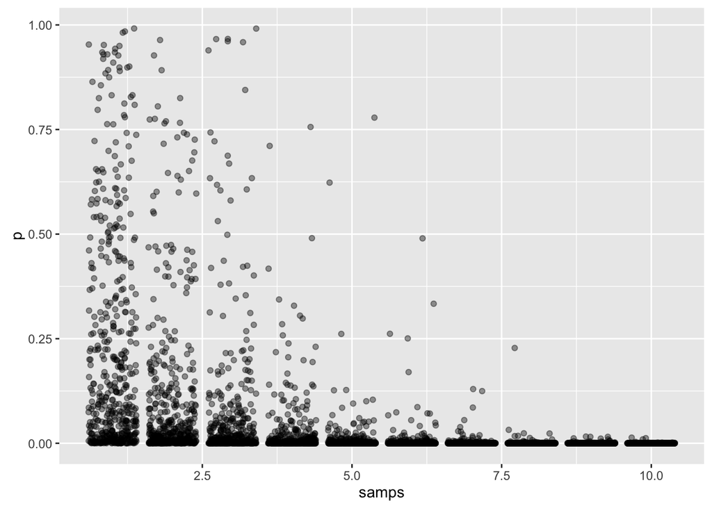

```r
ggplot(data = sim_data, mapping = aes(x=samps, y=p)) +
  geom_jitter(alpha=0.4)
```

### 4.3 Calculating Power

Now - power! We know that our type II error rate, beta, is the fraction of p values that are greater than our alpha (here 0.05). Great! Power is then 1 - beta.

Note, I’m going to use `n()` within a group here rather than trying to remember how big my number or replicate simulations for each sample size was. Protect yourself! Practice lazy coding!

```r
sim_power <- sim_data %>%
  group_by(samps) %>%
  summarise(power = 1-sum(p>0.05)/n()) %>%
  ungroup()
```

And we can plot that result with our critical threshold for power.

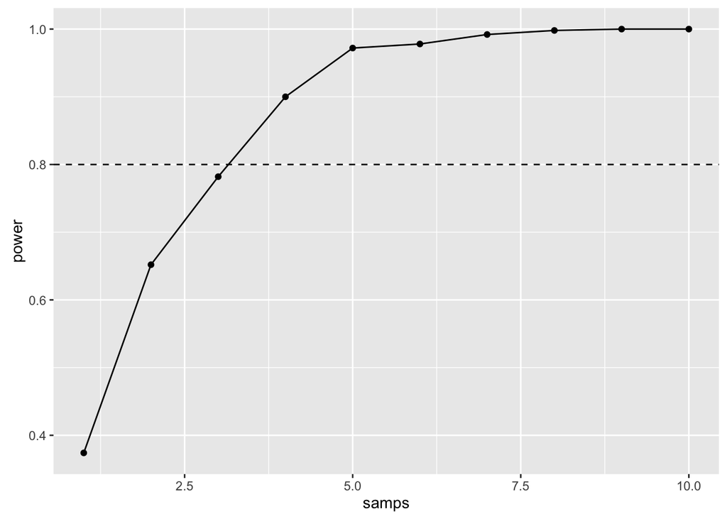

```r
ggplot(data=sim_power, mapping = aes(x=samps, y=power)) +
  geom_point() +
  geom_line() +
  geom_hline(yintercept=0.8, lty=2)
```

Wow - pretty good!

### 4.3 Exercise

OK, let’s take the above example, and now, assume that the drug only increased the BPM by 2, the population has a SD of 7, and our alpha is 0.01. What is our power?

### 4.3 Multiple Alphas

Let’s say we wanted to look at multiple alphas. Well, we’d need another column for alpha! And we want all possible combinations of alpha and the `sim_data`. For that, we can use a function in the `tidyr` library that does that sort of all possible combinations of values in two objects called `crossing()`.

```r
library(tidyr)

sim_tradeoff <- sim_data %>%

  #more alphas!
  crossing(alpha = 10^(-1:-10)) %>%

  #now calculate power for each alpha
  group_by(samps, alpha) %>%
  summarise(power = 1-sum(p>alpha)/500) %>%
  ungroup()
```

We can then plot this with `ggplot`

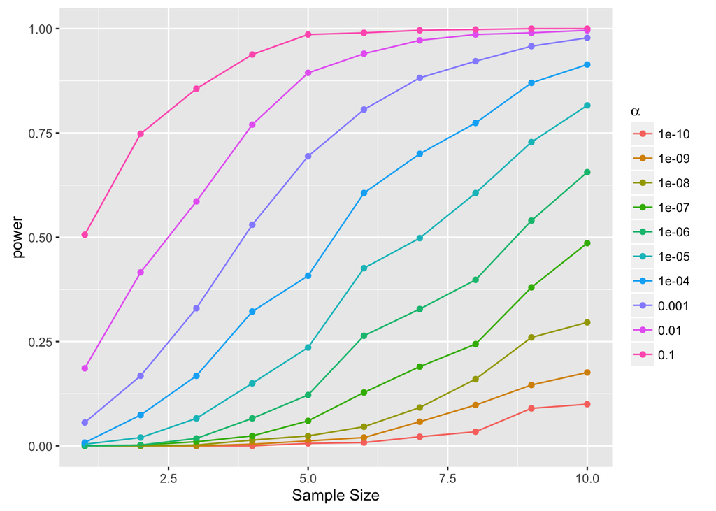

```r
ggplot(sim_tradeoff) +
  aes(x=samps, y=power, color=factor(alpha)) +
  geom_point() + geom_line() +
  xlab("Sample Size") +

  #just a little note on greek letters and re-titling
  #colorbars
  scale_color_discrete(guide = guide_legend(title=expression(alpha)))
```